# UA Flight Data Gain Analysis

Yinhui Yang

12/02/2022

# United Airlines Flight Data Gain Analysis Report

## Executive Summary

**OBJECTIVE**: Flight delays on airlines are common and have a big impact on both travelers and carriers. The study’s goal is to identify the average gain situation for flights.

**RESULTS**: The permutation tests with difference model results was just 0.002 which we conclude that there is a statistically significant difference in average gain and relative gain. Diagnostic histogram charts that indicate top 5 most common destination airports reveals a commonality in having similarly modal peak at a gain, and when we look at the average of top 5 most common destination airports average gain are between 5 to 10, so that we have strengthens reason to believe significant difference for each case.

**CONCLUSION**: Airlines report the reasons for delays in different major categories, but in-deep, flight delay, flight departure, flight arrival, and flight duration problems are the main causes of delays.

In conclusion, the dataset lacked the predictors necessary to fully account for air traffic congestion, delayed arrivals, boarding issues, personnel problems, and mechanical issues. This constitutes a study restriction. But we still could conclude that the flight delays and flight planning we have experienced thus far are serious problems. Therefore, in order to increase productivity and customer satisfaction, we would need to prioritize reducing flight delays, lengthening flights, and working on flight planning.

##### Summary of the UA flights gain

```
##     Min.  1st Qu.   Median     Mean  3rd Qu.     Max.     NA's
## -165.000   -1.000   10.000    8.459   20.000   74.000      883
```

##### Histogram of the gain distribution

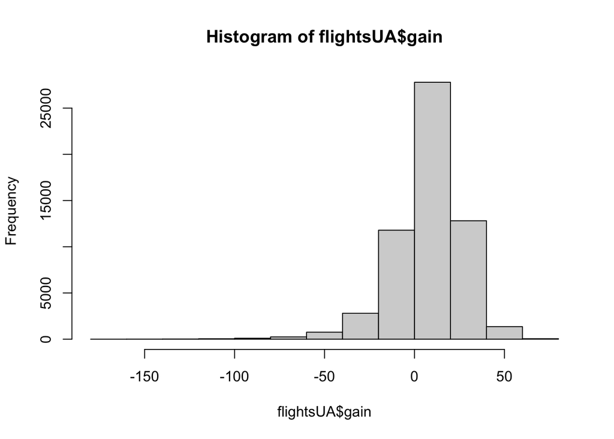

### 1. Does the average gain differ for flights that departed late versus those that did not? What about for flights that departed more than 30 minutes late?

#### Late Departure (dep_delay > 0)

$H_0:\overline{Gain}_{Late} = \overline{Gain}_{Late}$  
$H_1:\overline{Gain}_{Late} ≠ \overline{Gain}_{Late}$

```
##    FALSE     TRUE
## 9.269172 7.543115
```

```
## Permutation test result:
```

```
## [1] 0.002
```

Based on the above Late Departure (dep_delay > 0) permutation test results, we may conclude that there is a statistically significant difference in average gain between late flights and non-late flights because the p-value is 0.002, which is less than 0.05.

#### Very Late Departure (dep_delay >= 30)

$H_0:\overline{Gain}_{Very Late} = \overline{Gain}_{Very Late}$  
$H_1:\overline{Gain}_{Very Late} ≠ \overline{Gain}_{Very Late}$

```
##    FALSE     TRUE
## 8.696265 6.930613
```

```
## Permutation test result:
```

```
## [1] 0.002
```

Based on the above Very Late Departure (dep_delay >= 30) permutation test results, we may conclude that there is a statistically significant difference in average gain between very late flights and non-very late flights because the p-value is 0.002, which is less than 0.05.

### 2. What are the five most common destination airports for United Airlines flights from New York City?

##### Average gain performance for destinations

[output not shown]

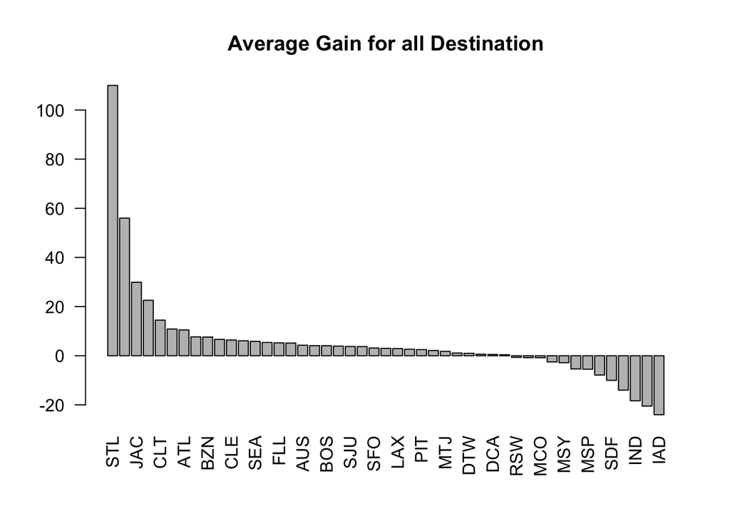

```
## numeric(0)
```

##### Top 5 most common destination airports

```
## # A tibble: 5 × 2
##   `flightsUA$dest`     n
##   <chr>            <int>
## 1 ORD               6984
## 2 IAH               6924
## 3 SFO               6819
## 4 LAX               5823
## 5 DEN               3796
```

##### Top 5 most common destination airports average gain

```
## # A tibble: 5 × 2
##   dest  average
##   <chr>   <dbl>
## 1 DEN      7.30
## 2 IAH      6.86
## 3 LAX      7.83
## 4 ORD      7.78
## 5 SFO      8.70
```

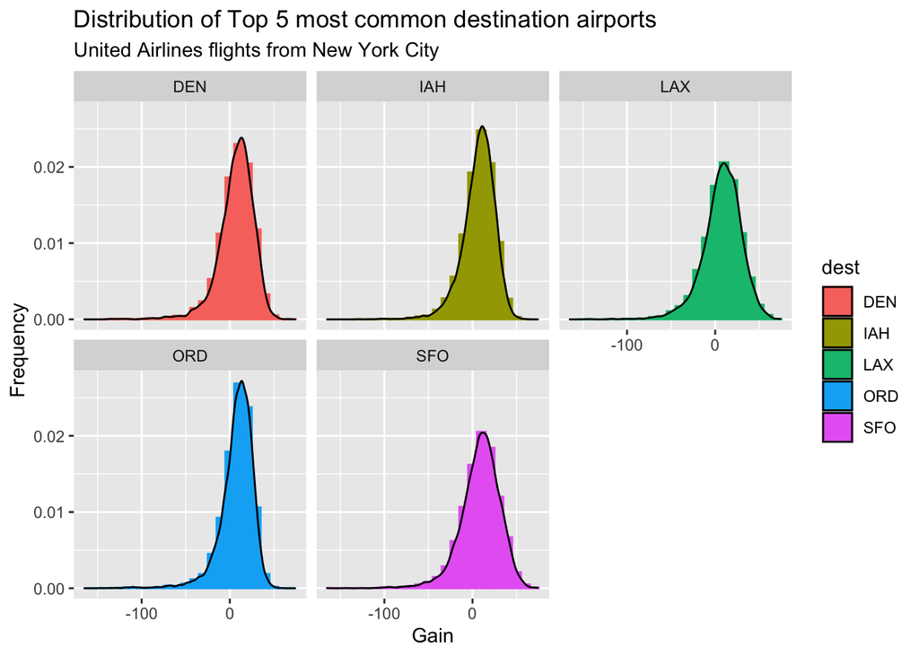

According to the above distribution of the gain for each of these top 5 airports is displayed in histograms. The distribution of each of these airports reveals a commonality in having a modal peak at a gain, and if we look at the average of top 5 most common destination airports average gain are between the range of 5 to 10. So for the frequency of the peak frequency varies depending on the number of airports that are destinations from New York airports.

### 3. Does the average gain per hour differ for flights that departed late versus those that did not? What about for flights that departed more than 30 minutes late?

$H_0:\overline{Relative Gain}_{late} = \overline{Relative Gain}_{late}$  
$H_1:\overline{Relative Gain}_{late} ≠ \overline{Relative Gain}_{late}$

```
##     FALSE      TRUE
## 0.9310086 0.6274405
```

```
## Permutation test result:
```

```
## [1] 0.002
```

$H_0:\overline{Relative Gain}_{Very Late} = \overline{Relative Gain}_{Very Late}$  
$H_1:\overline{Relative Gain}_{Very Late} ≠ \overline{Relative Gain}_{Very Late}$

```
##     FALSE      TRUE
## 0.8334484 0.4991203
```

```
## Permutation test result:
```

```
## [1] 0.002
```

### 4. Does the average gain per hour differ for longer flights versus shorter flights?

```
## Average flights in mintues:
```

```
## [1] 211.7914
```

#### Flight Duration

$H_0: Gain_{Average,t \underline{>}212} = Gain_{Average,t <212}$  
$H_1: Gain_{Average,t \underline{>}212} ≠ Gain_{Average,t <212}$

```
##     FALSE      TRUE
## 0.8522031 0.7053551
```

```
## Permutation test result:
```

```
## [1] 0.002
```

Based on the above Flight Duration Relative Gain permutation test results, we may conclude that there is a statistically significant difference in average relative gain between long flights and short flights because the p-value is 0.002, which is less than 0.05.